# Lecture 15: Overview of Further Topics

STA310 Survival Analysis · Collett Chapters 9, 10 and 15

2026-10-06

## Today

This is an **overview** lecture (Zoom). Three topics at the edge of the course:

- **A.** Interval-censored data (Chapter 9)
- **B.** Frailty models (Chapter 10)
- **C.** Sample size and power (Chapter 15)

Pace: moderate. Everything is self-explanatory; read the slides, run the code afterwards.

**Learning goals**

You can

- recognise interval-censored data and write down its likelihood
- fit non-parametric, semi-parametric and parametric models for it in R
- explain what a frailty is and what a shared frailty model does
- compute the number of events and patients needed for a trial
- check power by simulation

## Not exam-critical

These topics are **not** core material. The goal is:

- know the problem and why the standard tools fail
- know which method and which R function to reach for
- see one working example of each

Full theory is in Collett; we do not derive anything today.

# Part A: Interval-censored data

## Motivation: we do not always see the event

The event is something we **detect at a visit**, not something we observe happening.

| Study | Event | What we know |
| --- | --- | --- |
| Ulcer trial, endoscopy at 6 and 12 months | Ulcer recurrence | Absent at month 6, present at month 12 |
| Cohort with cognitive tests every 2 years | Onset of dementia | Normal at 70, impaired at 72 |
| HIV testing programme | Seroconversion | Negative in 2018, positive in 2021 |
| Cancer follow-up scans | Recurrence | Scan clear in March, tumour seen in September |

The event time $T$ is only known to lie in an interval $(L, R]$ between two visits.

## Definition

$$L < T \le R$$

| Situation | $(L, R]$ |
| --- | --- |
| Exact event time $t$ | $L = R = t$ |
| Right-censored at $t$ | $(t, \infty)$ |
| Left-censored at $t$ (already present at first visit) | $(0, t]$ |
| Interval-censored | $(L, R]$ with $0 < L < R < \infty$ |

Right and left censoring are **special cases** of interval censoring. In R: `Surv(L, R, type = "interval2")` (with `R = Inf` for right-censored).

*Current status data*: one single visit per person. Everyone is either left- or right-censored.

## A picture

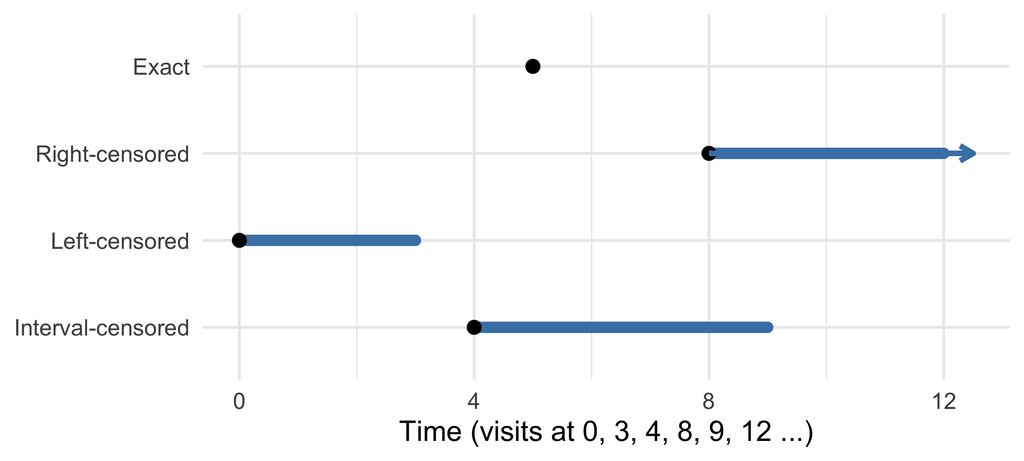

## Why not just use the visit times?

Tempting shortcuts:

1. use the **right endpoint** $R$ as event time (“detected at”)
2. use the **midpoint** $(L + R)/2$
3. use the **left endpoint** $L$

Problems:

- All three **invent** exact times that were never observed
- Right endpoint: event times are overestimated; midpoint: artificial times; both depend on the **visit schedule**, not only on biology
- Different visit schedules in the two arms (e.g. a treatment that suppresses symptoms) give **biased treatment comparisons** (Collett, Section 9.1)
- Standard errors are too small, as the uncertainty about the time is ignored

Shortcuts are acceptable only when the intervals are very short relative to the study length.

## The likelihood contribution

Individual $i$ with $T_i \in (L_i, R_i]$ contributes the **probability of that interval**:

$$P(L_i < T_i \le R_i) = S(L_i) - S(R_i)$$

$$\mathcal{L} = \prod_{i} \big[ S(L_i) - S(R_i) \big]$$

- Exact time: $S(t^-) - S(t)$ becomes the density $f(t)$ (usual contribution)
- Right-censored: $R = \infty$, $S(\infty) = 0$, contribution $S(L)$ (usual contribution)
- Left-censored: $L = 0$, $S(0) = 1$, contribution $1 - S(R) = F(R)$

So **one formula** covers all censoring types. With a parametric $S(t)$ we maximise it directly; semi-parametric models need an additional idea (next slides).

## Non-parametric estimation: Turnbull (idea only)

Kaplan–Meier needs exact event times. Here the “steps” can only happen **somewhere inside** certain intervals.

**Idea** (Turnbull’s NPMLE):

1. Sort all $L$ and $R$ values. The *Turnbull intervals* are those that start with an $L$ and end with an $R$ with no other endpoints in between.
2. The likelihood only depends on how much probability mass sits in each Turnbull interval.
3. Maximise iteratively (EM algorithm): distribute each person’s mass across the intervals compatible with their data, update, repeat.

**Consequences**

- $\hat S(t)$ is **flat** between Turnbull intervals
- *Inside* a Turnbull interval $\hat S$ is not identifiable. We only know the drop in total.
- With exact times it reduces to Kaplan–Meier
- R: `icenReg::ic_np()`

## Naive KM vs Turnbull: a simulation

True times are Weibull; patients are seen every 3 time units until time 15.

```r
set.seed(8317)
n <- 300
t_true <- rweibull(n, shape = 1.5, scale = 10)
visit <- seq(0, 15, by = 3)
L <- visit[findInterval(t_true, visit, left.open = TRUE)]    # last visit before event
R <- ifelse(t_true > 15, Inf, L + 3)                          # first visit after event
head(cbind(t_true, L, R), 4)
```

```
         t_true L  R
[1,]  9.5526225 9 12
[2,]  9.5623951 9 12
[3,] 11.7561973 9 12
[4,]  0.3910082 0  3
```

```r
fit_turnbull <- icenReg::ic_np(cbind(L, R) ~ 0, data = data.frame(L, R))
sc <- icenReg::getSCurves(fit_turnbull)
```

## Naive KM vs Turnbull: the plot

The Turnbull estimate is only determined at the upper ends of the Turnbull intervals (here the visit times 3, 6, …, 15), so we compare at these times.

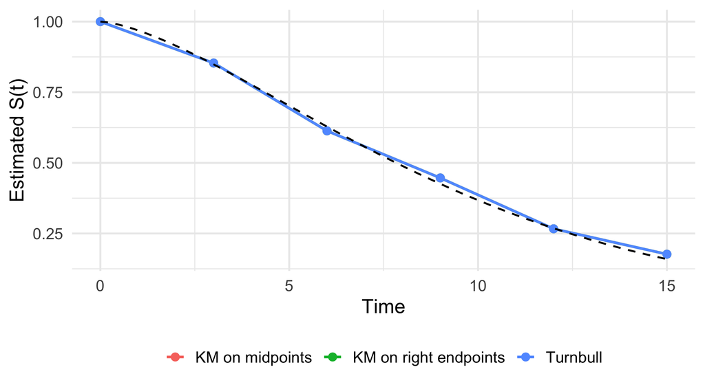

```r
mid <- ifelse(is.infinite(R), 15, (L + R) / 2)   # midpoint; censored at 15
km_mid <- survfit(Surv(mid, is.finite(R)) ~ 1)
km_right <- survfit(Surv(ifelse(is.infinite(R), 15, R), is.finite(R)) ~ 1)

tt <- seq(3, 15, by = 3)
cmp <- bind_rows(
  tibble(time = c(0, tt), S = c(1, summary(km_mid, times = tt, extend = TRUE)$surv), method = "KM on midpoints"),
  tibble(time = c(0, tt), S = c(1, summary(km_right, times = tt, extend = TRUE)$surv), method = "KM on right endpoints"),
  # the first Turnbull "interval" is a point mass at 0, so values 2:6 belong to t = 3, ..., 15
  tibble(time = c(0, tt), S = c(1, sc$S_curves$baseline[2:6]), method = "Turnbull"))
ggplot(cmp, aes(time, S, colour = method)) +
  geom_line(linewidth = 1) + geom_point(size = 2.5) +
  stat_function(fun = \(x) pweibull(x, 1.5, 10, lower.tail = FALSE), colour = "black", linetype = 2) +
  labs(x = "Time", y = "Estimated S(t)", colour = NULL) + theme(legend.position = "bottom")
```

Dashed black: the true $S(t)$.

## Reading the plot

**Warning**

The size of the bias depends on the visit schedule. Wider intervals mean more bias.

## Example: recurrence of an ulcer (Collett Example 9.1)

43 patients (Belgian centre), endoscopy at 6 and 12 months, plus unscheduled visits when symptoms occurred. Variables: `age`, `duration` (1: < 5 years, 2: $\ge$ 5 years), `treatment` (A, B), `time` of last visit, `result` (1 = no ulcer, 2 = ulcer).

Conversion to $(L, R]$ as in Table 9.2 of the book:

```r
ulcer |> count(time, result, L, R) |> head(9)
```

```
  time result  L   R  n
1    2      2  0   2  1
2    3      2  0   3  1
3    5      2  0   5  1
4    6      1  6 Inf  3
5    6      2  0   6  2
6    7      2  6   7  2
7   10      2  6  10  1
8   12      1 12 Inf 29
9   12      2  6  12  3
```

Checked: all nine combinations agree with Collett Table 9.2, e.g. 12 months with a negative result is $(12, \infty]$.

## Turnbull curves by treatment

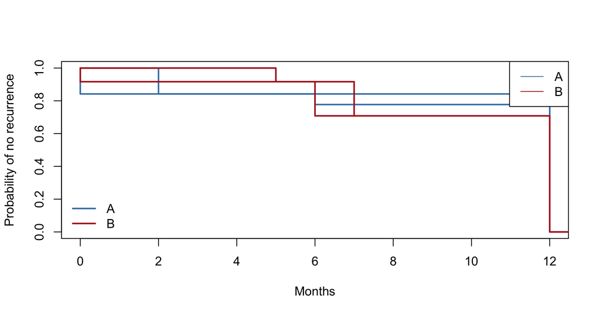

```r
fit_np <- icenReg::ic_np(cbind(L, R) ~ trt, data = ulcer)
plot(fit_np, col = c("steelblue", "firebrick"), lwd = 2, xlab = "Months", ylab = "Probability of no recurrence")
legend("bottomleft", legend = c("A", "B"), col = c("steelblue", "firebrick"), lwd = 2, bty = "n")
```

## Regression models for interval-censored data

| Model | R function | Baseline |
| --- | --- | --- |
| Cox PH, **semi-parametric** | `icenReg::ic_sp(..., model = "ph")` | step function (NPMLE) |
| Proportional odds, semi-parametric | `icenReg::ic_sp(..., model = "po")` | step function |
| PH / PO / AFT, **parametric** | `icenReg::ic_par()` | Weibull, lognormal, … |
| Parametric AFT | `survival::survreg(Surv(L, R, type = "interval2") ~ ...)` | Weibull, lognormal, … |

The Cox model is not as simple as with exact times: the baseline survivor function and $\beta$ must be estimated together by maximising $\prod [S(L_i) - S(R_i)]$. Standard errors are best obtained by **bootstrap**.

## Semi-parametric Cox model with `ic_sp`

```r
set.seed(5902)
fit_sp <- icenReg::ic_sp(cbind(L, R) ~ trt + age + dur, data = ulcer, bs_samples = 200)
summary(fit_sp)
```

```
Model:  Cox PH
Dependency structure assumed: Independence
Baseline:  semi-parametric
Call: icenReg::ic_sp(formula = cbind(L, R) ~ trt + age + dur, data = ulcer,
    bs_samples = 200)

              Estimate Exp(Est) Std.Error z-value      p
trtB          0.215500   1.2400   1.31900  0.1633 0.8703
age          -0.010540   0.9895   0.03251 -0.3243 0.7457
dur>=5 years -0.009952   0.9901   2.31500 -0.0043 0.9966

final llk =  -31.28288
Iterations =  7
Bootstrap Samples =  200
```

Hazard ratio for treatment B vs A: 1.24, but with a very wide interval. Nothing here is distinguishable from no effect (age and duration also show no effect). The bootstrap samples are random, so SE vary slightly between runs.

## Parametric AFT with `survreg`

```r
fit_aft <- survreg(Surv(L, R, type = "interval2") ~ trt + age + dur,
                   data = ulcer, dist = "weibull")
summary(fit_aft)$table |> round(3)
```

```
              Value Std. Error      z     p
(Intercept)   3.405      1.284  2.652 0.008
trtB         -0.285      0.733 -0.389 0.697
age           0.012      0.022  0.557 0.578
dur>=5 years -0.018      0.786 -0.023 0.982
Log(scale)    0.139      0.395  0.351 0.725
```

- `type = "interval2"`: `L` and `R` as two columns; `R = Inf` (or `NA`) means right-censored.
- Time ratio for B vs A: 0.75. Recurrence free times are about 25% shorter on B, but $p =$ 0.7.
- Weibull shape: $1/\text{scale} =$ 0.87.

Same conclusion as the semi-parametric model (B slightly worse, not significantly). Direction agrees: HR > 1 in the PH model means shorter times, time ratio < 1 in the AFT model.

## What the naive analysis would give

Using the visit time as if the recurrence were exact (event = ulcer found):

```r
naive <- coxph(Surv(time, result == 2) ~ trt + age + dur, data = ulcer)
bind_rows(naive = broom::tidy(naive, exponentiate = TRUE)[1, ],
          interval = tibble(term = "trtB", estimate = exp(coef(fit_sp)["trtB"])),
          .id = "analysis") |>
  select(analysis, term, HR = estimate)
```

```
# A tibble: 2 × 3
  analysis term     HR
  <chr>    <chr> <dbl>
1 naive    trtB   1.25
2 interval trtB   1.24
```

**Note**

In the book’s ulcer trial, the *detection mechanism* may differ by treatment (symptom suppression). Interval-based methods help with timing, but not with a detection that depends on the treatment.

## Part A: practical notes

- **Left-truncation vs censoring**: do not confuse; interval censoring is about *how precisely* $T$ is seen.
- **Independent inspection times** are assumed: the visit schedule must not depend on the (unobserved) event time.
- Many standard tools exist in the interval-censored setting too: `icenReg` also provides `ic_par` with Weibull, lognormal, gamma and others; `survreg` handles any AFT distribution.
- Dementia, HIV and ulcer data are the typical examples, but **almost all data are interval-censored** to some degree (days rounded). It only matters when intervals are wide.
- `icenReg` also ships example data, e.g. `IR_diabetes` (age at diabetes onset, mostly exact times plus intervals) and `miceData`.

## Think about (Part A)

1. A patient has a negative scan at month 6 and a positive scan at month 12. What is $(L, R]$? What do we know if the scan at month 12 was never done?
2. Why does `Surv(time, status)` with $R$ as the time overestimate survival?
3. What would the likelihood contribution be for a patient first seen at month 4 who already has the disease?

# Part B: Frailty models

## Motivation: heterogeneity we cannot measure

Two patients with the same covariates can still have different hazards: genetics, lifestyle, centre, donor quality, unmeasured disease severity.

*Frailty* $z$: an **unobserved, multiplicative factor** on the hazard.

- individual frailty: heterogeneity between persons
- **shared frailty**: persons from the same *cluster* share the same $z$

Clustered data (centres, paired organs, families) are **correlated**: the usual independence assumption fails. Recurrent events in the same person are one case; their data layout and the marginal AG/PWP approach are in **Lecture 14**, here we look at the frailty alternative.

## The shared frailty model

For individual $j$ in cluster $i$ (Collett, Equation 10.31):

$$h_{ij}(t) = z_i \, h_0(t) \exp(\beta' x_{ij}) = h_0(t)\exp(\beta' x_{ij} + u_i), \qquad u_i = \log z_i$$

- $z_i > 0$ is the cluster’s frailty, shared by all $n_i$ members
- $z_i$ is **random**, drawn from a distribution with mean 1 (gamma) or $u_i \sim N(0, \sigma^2)$ (log-normal)
- Large $z_i$: the whole cluster is at higher risk; this creates correlation within the cluster
- Variance parameter $\theta = \text{Var}(z_i)$ (gamma) or $\sigma^2$ (log-normal): $\theta = 0$ means no heterogeneity, i.e. the ordinary Cox model

## Interpreting the variance

- Variance **small**: clusters are similar, the model is close to a standard Cox model.
- Variance **large**: strong cluster effects.
- For the log-normal frailty with $\sigma^2$: a cluster at +1 SD has hazard multiplied by $e^{\sigma}$ compared to an average cluster. For example, $\sigma^2 = 0.3$ gives $e^{\sqrt{0.3}} =$ 1.73.
- For the gamma frailty, within-cluster association can be expressed as Kendall’s $\tau = \theta/(\theta + 2)$ with the usual parametrisation (mean 1, variance $\theta$).

Testing $H_0: \theta = 0$ is a test on the **boundary** of the parameter space: use a mixture $0.5\chi^2_0 + 0.5\chi^2_1$, which halves the usual $p$-value. Note that the test printed by `coxph` with `frailty()` is a different, approximate chi-square test (non-integer degrees of freedom, about 11 below), so it is not this boundary test.

## Conditional vs marginal hazard ratios

**Conditional** (frailty model)

HR comparing two individuals **in the same cluster** (same frailty).

$\exp(\beta)$ is the within-cluster effect.

**Marginal** (population-averaged)

HR averaged over the frailty distribution.

Typically **closer to 1** than the conditional HR, because the high-frailty individuals die early and the group left over differs.

The marginal approach (Cox model + `cluster()` for **robust variance**) estimates the population-average effect and corrects the standard errors for within-cluster correlation, but does *not* model the cluster effect and cannot estimate the variance.

## Fitting in R

```r
# Gamma frailty (default): penalised likelihood
coxph(Surv(time, status) ~ x1 + x2 + frailty(cluster), data = d)

# Log-normal (Gaussian) frailty
coxph(Surv(time, status) ~ x1 + x2 + frailty(cluster, dist = "gauss"), data = d)

# Marginal model with cluster-robust standard errors
coxph(Surv(time, status) ~ x1 + x2 + cluster(cluster), data = d)
```

**Note**

`frailty()` in `survival` is the older interface and is penalised-likelihood based. The modern alternative is `coxme::coxme(... + (1 | cluster))`, which is more flexible (several random effects, better handling of the variance). `coxme` is **not installed** here, so we use `frailty()`.

## Example: kidney transplantation (Collett Example 10.4)

Both kidneys from one deceased donor are transplanted into two recipients. 434 recipients, 270 donors. Outcome: transplant survival. Covariates: age, diabetes (0/1), cold ischaemic time `cit` (hours).

```r
kidney_tx |> count(donor) |> count(n, name = "donors") |> rename(recipients_per_donor = n)
```

```
  recipients_per_donor donors
1                    1    106
2                    2    164
```

71 events among 434 recipients. Of the 270 donors, 164 gave two recipients, so there is room for a **donor effect** shared by the pair.

## Cox model ignoring the donor

```r
fit0 <- coxph(Surv(time, status) ~ age + diabetes + cit, data = kidney_tx)
broom::tidy(fit0, exponentiate = TRUE, conf.int = TRUE) |>
  select(term, HR = estimate, conf.low, conf.high, p.value) |> mutate(across(where(is.numeric), \(x) round(x, 3)))
```

```
# A tibble: 3 × 5
  term        HR conf.low conf.high p.value
  <chr>    <dbl>    <dbl>     <dbl>   <dbl>
1 age      1.02     0.999      1.04   0.06
2 diabetes 0.802    0.341      1.89   0.614
3 cit      1.02     0.982      1.07   0.262
```

Hazard ratio per year of age: 1.019.

## Shared gamma and log-normal frailty

```r
fit_g <- coxph(Surv(time, status) ~ age + diabetes + cit + frailty(donor), data = kidney_tx)
fit_n <- coxph(Surv(time, status) ~ age + diabetes + cit + frailty(donor, dist = "gauss"), data = kidney_tx)
fit_g
```

```
Call:
coxph(formula = Surv(time, status) ~ age + diabetes + cit + frailty(donor),
    data = kidney_tx)

                  coef se(coef)     se2   Chisq   DF     p
age             0.0189   0.0103  0.0101  3.3896  1.0 0.066
diabetes       -0.2386   0.4440  0.4374  0.2888  1.0 0.591
cit             0.0238   0.0215  0.0211  1.2197  1.0 0.269
frailty(donor)                          11.9769 11.4 0.399

Iterations: 4 outer, 18 Newton-Raphson
     Variance of random effect= 0.169   I-likelihood = -415.8
Degrees of freedom for terms=  1.0  1.0  1.0 11.4
Likelihood ratio test=27.3  on 14.3 df, p=0.02
n= 434, number of events= 71
```

## Reading the output

Conclusion (as in the book): there is no clear evidence of a donor effect on short-term transplant survival, and ignoring it does not materially change the conclusions. With only 71 events and mostly pairs, the variance is hard to estimate precisely.

## The marginal alternative: robust variance

```r
fit_rob <- coxph(Surv(time, status) ~ age + diabetes + cit + cluster(donor), data = kidney_tx)
tibble(term = names(coef(fit0)), estimate = coef(fit0),
       SE_naive = summary(fit_rob)$coefficients[, "se(coef)"],
       SE_robust = summary(fit_rob)$coefficients[, "robust se"]) |>
  mutate(across(where(is.numeric), \(x) round(x, 4)))
```

```
# A tibble: 3 × 4
  term     estimate SE_naive SE_robust
  <chr>       <dbl>    <dbl>     <dbl>
1 age        0.019    0.0101    0.0109
2 diabetes  -0.220    0.436     0.391
3 cit        0.0237   0.0211    0.0223
```

Same point estimates; only the standard errors change. Here the robust SE are close to the naive ones, in line with a small donor effect. When clusters are strongly correlated and the covariate varies **between** clusters, the robust SE can be considerably larger.

## Another example: infections on dialysis (`survival::kidney`)

38 patients (data set `kidney` from `survival`, not the transplant data `kidney_tx` above), each with **two** times to infection at the catheter insertion site. These are recurrent events: the marginal AG approach is in Lecture 14, here we use a frailty per patient.

```r
fit_k <- suppressWarnings(coxph(Surv(time, status) ~ age + sex + frailty(id), data = kidney))
fit_k2 <- coxph(Surv(time, status) ~ age + sex + cluster(id), data = kidney)
fit_k
```

```
Call:
coxph(formula = Surv(time, status) ~ age + sex + frailty(id),
    data = kidney)

                coef se(coef)      se2    Chisq DF       p
age          0.00525  0.01189  0.00880  0.19515  1 0.65867
sex         -1.58749  0.46055  0.35200 11.88114  1 0.00057
frailty(id)                            23.12952 13 0.04036

Iterations: 7 outer, 65 Newton-Raphson
     Variance of random effect= 0.412   I-likelihood = -181.6
Degrees of freedom for terms=  0.5  0.6 13.0
Likelihood ratio test=46.8  on 14.1 df, p=2e-05
n= 76, number of events= 58
```

**Note**

For this gamma frailty fit `coxph` warns “Inner loop failed to converge for iterations 3” (one inner Newton step of the penalised likelihood; the outer iterations finish normally). The Gaussian, non-sparse and fixed-theta variants give the same conclusion (large sex effect), so we suppress the warning with `suppressWarnings()`. Treat the variance estimate as approximate.

The frailty variance is 0.41: here there is moderate heterogeneity between patients (the test of the frailty term gives $p =$ 0.04). Female patients (`sex = 2`) have a **conditional** hazard ratio of 0.2, but the **marginal** (robust) model gives 0.44: the marginal effect is closer to 1, as discussed earlier.

**Note**

The dataset has a column `frail`, which is **an estimate from an old analysis**, not a real covariate. Do not use it as a predictor.

## A classic: heterogeneity shapes the population hazard

Suppose **every individual has a constant hazard** $z_i \lambda$, with gamma frailty $z_i$ (mean 1, variance $\theta$). What does the population look like?

$$h_{\text{pop}}(t) = \frac{\lambda}{1 + \theta \lambda t}$$

The population hazard **decreases**, although no individual’s hazard does. The frail die first; the survivors are the robust ones (selection).

Consequences:

- An observed declining hazard can be a **heterogeneity artefact**, not a biological decline
- Treatment effects: the marginal HR tends to **attenuate towards 1** with time, which can look like non-proportional hazards (see Lecture 11)

## Simulation

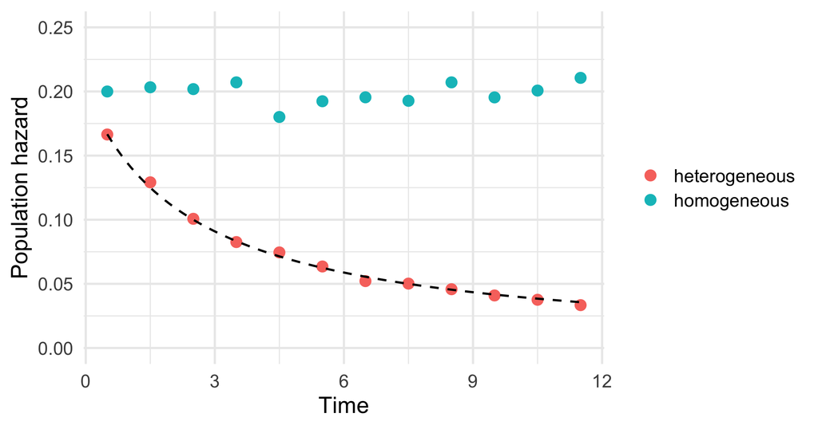

```r
set.seed(6104)
n <- 20000; lambda <- 0.2; theta <- 2
z <- rgamma(n, shape = 1 / theta, scale = theta)      # mean 1, variance theta
t_ind <- rexp(n, rate = lambda * z)                   # constant individual hazards
t_hom <- rexp(n, rate = lambda)                       # homogeneous population

emp_haz <- function(t, breaks) {                      # events per unit person-time in bins
  tibble(bin = cut(t, breaks)) |> filter(!is.na(bin)) |> count(bin, name = "events") |>
    mutate(mid = breaks[-length(breaks)][as.integer(bin)] + diff(breaks)[1] / 2,
           pt = map_dbl(as.integer(bin), \(k) sum(pmin(pmax(t - breaks[k], 0), diff(breaks)[1]))),
           hazard = events / pt)
}
br <- seq(0, 12, by = 1)
bind_rows(heterogeneous = emp_haz(t_ind, br), homogeneous = emp_haz(t_hom, br), .id = "population") |>
  ggplot(aes(mid, hazard, colour = population)) + geom_point(size = 3) +
  stat_function(fun = \(t) lambda / (1 + theta * lambda * t), colour = "black", linetype = 2) +
  labs(x = "Time", y = "Population hazard", colour = NULL) + ylim(0, 0.25)
```

Dashed: the formula above with $\theta = 2$. Every individual in the “heterogeneous” population has a constant hazard.

## Part B: pitfalls and practical advice

- Frailty is **not identifiable** from a single event per person with no covariates and an unspecified baseline: the data cannot separate heterogeneity from the shape of $h_0$. Clusters with several members are what give information.
- The **distribution** (gamma vs log-normal) is usually not testable; conclusions are rarely sensitive to it.
- Conditional vs marginal: report which one you estimate.
- Few events per cluster and small clusters give imprecise variance estimates.
- Choose by the **question**: interest in the cluster-level variation or a prediction within clusters: frailty model. Only the population-average effect: marginal model with `cluster()`.
- `coxme` (not installed) is the preferred tool for a log-normal frailty in practice.

## Think about (Part B)

1. Two patients get kidneys from the same donor. Why would we expect their outcomes to be correlated, even after adjusting for age?
2. If the frailty variance is estimated as 0, what model do we get?
3. A hazard ratio from a gamma frailty model is $0.6$. Is it the same as the HR from a marginal model? Which tends to be nearer to 1?

# Part C: Sample size and power

## The key principle: events, not patients

The log-rank test (and Cox score test) has power determined by **the number of events** $d$, not by $n$:

- 1000 patients with 20 events carry less information than 100 patients with 80 events
- The planning therefore has two steps:
  1. how many **events** $d$ do we need?
  2. how many **patients** $n$ (and how long a study) to get $d$ events?

Setting: two groups, hazard ratio $\psi$ (new vs standard), significance level $\alpha$, power $1 - \beta$, log-rank test.

## Schoenfeld’s formula

Number of events required to detect a log hazard ratio $\log \psi_R$:

$$d = \frac{(z_{1-\alpha/2} + z_{1-\beta})^2}{p_1 p_2 \, (\log \psi_R)^2}$$

where $p_1, p_2$ are the proportions allocated to the groups. For equal allocation, $p_1 p_2 = 1/4$, and this is Collett’s Equation 15.1, $d = 4(z_{\alpha/2} + z_\beta)^2/\theta_R^2$ (Collett’s $\theta_R$ is our $\log\psi_R$).

```r
schoenfeld <- function(hr, alpha = 0.05, power = 0.9, p1 = 0.5) {
  (qnorm(1 - alpha / 2) + qnorm(power))^2 / (p1 * (1 - p1) * log(hr)^2)
}
schoenfeld(0.57)
```

```
[1] 133.0148
```

## Worked example: chronic active hepatitis (Collett Example 15.1)

A trial of a new treatment. In the standard arm 5-year survival is $S_S(5) = 0.41$; the new treatment is expected to give $S_N(5) = 0.60$. Under proportional hazards $S_N = S_S^{\psi}$, so

```r
psi <- log(0.60) / log(0.41)
psi
```

```
[1] 0.5729326
```

```r
d <- schoenfeld(0.57, alpha = 0.05, power = 0.90)
c(exact = d, rounded_up = ceiling(d / 10) * 10)
```

```
     exact rounded_up
  133.0148   140.0000
```

About 133 events, rounded up to 140 as in the book (about 70 per arm); the formula is an approximation that tends to underestimate slightly.

## Sensitivity to the assumed effect

```r
tibble(HR = c(0.5, 0.57, 0.65, 0.78, 0.9)) |>
  mutate(events_80 = ceiling(schoenfeld(HR, power = 0.8)),
         events_90 = ceiling(schoenfeld(HR, power = 0.9)))
```

```
# A tibble: 5 × 3
     HR events_80 events_90
  <dbl>     <dbl>     <dbl>
1  0.5         66        88
2  0.57       100       134
3  0.65       170       227
4  0.78       509       681
5  0.9       2829      3787
```

## The data behind the example

The book data (Appendix B.1) are the 44 patients of the trial described by Kirk *et al.* (1980): randomised to prednisolone or an untreated control, with survival time **in months** (so 60 = 5 years). `treatment` 1 = prednisolone, 2 = control.

```r
fit_h <- survfit(Surv(time, status) ~ treatment, data = hepatitis)
summary(fit_h, times = 60)$surv |> round(2)
```

```
[1] 0.82 0.41
```

Estimated 5-year survival (60 months). The control arm (treatment 2) gives 0.41 — the book’s Example 15.1 standard-therapy rate (its median of 3.3 years is this same control arm expressed in years) — while prednisolone (treatment 1) gives 0.82, i.e. the drug actually did better than the 0.60 used in the planning calculation. With 27 events in 44 patients the observed HR (0.44, prednisolone vs control) is very imprecise, and the planning value 0.57 is more conservative. Pilot estimates are noisy: be careful when choosing $\psi_R$.

## From events to patients

$$n = \frac{d}{P(\text{event})}$$

$P(\text{event})$ is the probability that a randomly chosen patient has an event **before the study ends**.

- patients enter uniformly during an **accrual** period $a$
- then they are followed for another period $f$ (**follow-up**), total study length $a + f$
- a patient entering at time $u$ is followed for $a + f - u$

With exponential survival ($S(t) = e^{-\lambda t}$) and uniform accrual:

$$P(\text{event}) = 1 - \frac{1}{a}\int_f^{a+f} e^{-\lambda t}\,dt = 1 - \frac{e^{-\lambda f} - e^{-\lambda (a + f)}}{\lambda a}$$

Average over the two arms (hazards $\lambda_S$ and $\psi \lambda_S$).

## Events to patients in R

Assume exponential survival with $S_S(60 \text{ months}) = 0.41$. Accrual $a = 18$, follow-up $f = 24$ months.

```r
p_event <- function(lambda, a, f) 1 - (exp(-lambda * f) - exp(-lambda * (a + f))) / (lambda * a)

d_plan <- 140                      # events from Schoenfeld, rounded up (book)
lam_S <- -log(0.41) / 60           # per month
lam_N <- 0.57 * lam_S
pe <- mean(c(p_event(lam_S, 18, 24), p_event(lam_N, 18, 24)))
n_exp <- ceiling(d_plan / pe)
c(P_event = pe, n = n_exp, per_month = n_exp / 18)
```

```
    P_event           n   per_month
  0.3144482 446.0000000  24.7777778
```

Collett finds $P = 0.350$ and $n = 400$ (393 in a variant, Section 15.3) using the **observed** Kaplan-Meier curve and Simpson’s rule (Eq. 15.11). Our exponential model gives $P =$ 0.314, hence **446 patients** (about 25 per month over 18 months). The difference arises because an exponential curve through $S_S(5) = 0.41$ differs from the observed survival curve at the times that matter here, so fewer events per patient are expected than with the observed curve. Both are rough planning values.

## Accrual and follow-up

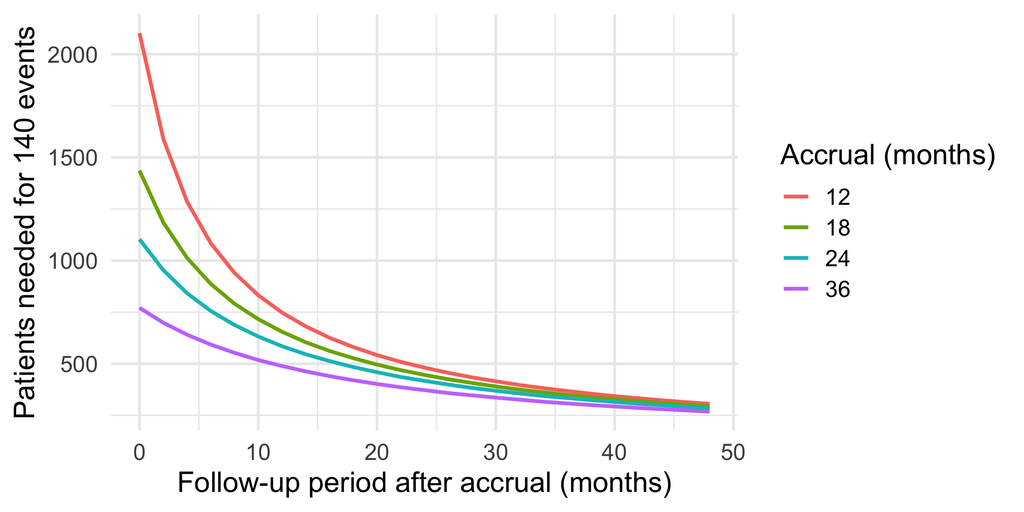

```r
grid <- expand_grid(a = c(12, 18, 24, 36), f = seq(0, 48, by = 2)) |>
  mutate(pe = map2_dbl(a, f, \(a, f) mean(c(p_event(lam_S, a, f), p_event(lam_N, a, f)))),
         n = ceiling(d_plan / pe))
ggplot(grid, aes(f, n, colour = factor(a))) + geom_line(linewidth = 1) +
  labs(x = "Follow-up period after accrual (months)", y = "Patients needed for 140 events", colour = "Accrual (months)")
```

No follow-up means many more patients. In a trial with a fixed budget of patients, extending **follow-up** is usually cheaper than recruiting more, until the curve flattens.

## What else changes the answer

| Factor | Effect | What to do |
| --- | --- | --- |
| Loss to follow-up / competing deaths | Fewer events per patient | Inflate $n$, e.g. by $1/(1 - \text{dropout})$ (rough); or include in simulation |
| Slow accrual | Longer study | Extend $a$ or $f$ |
| Non-proportional hazards (delayed or waning effect, crossing curves) | Log-rank test loses power, HR not well defined | Weighted log-rank, RMST (see Lecture 11); simulate under realistic curves |
| Clustering (centres, families) | Events carry less independent information | Inflate by a design effect, approx. $1 + (m - 1)\rho$; plan with a frailty model |
| More covariates adjustment | Small gain in precision (in Cox models) | Ignore in planning, typically |
| Interim analyses | Alpha is spent | Group sequential design (`gsDesign`) |

**Note**

`powerSurvEpi` and `gsDesign` are specialised packages for sample size and group sequential design. They are **not installed** here, so we use base R.

## Check by simulation

When formulas get complicated, **simulate the trial** many times and count rejections.

```r
sim_power <- function(n, hr, lambda0, a, f, dropout = 0, delay = 0, nsim = 1000) {
  mean(replicate(nsim, {
    arm <- rep(0:1, length.out = n)
    entry <- runif(n, 0, a)
    t_ev <- rexp(n, lambda0)                         # control arm; treated: hazard lambda0 until `delay`,
    t_trt <- ifelse(t_ev <= delay, t_ev, delay + rexp(n, hr * lambda0))   # then hr * lambda0 (memoryless)
    t_ev <- ifelse(arm == 1, t_trt, t_ev)
    t_lo <- if (dropout > 0) rexp(n, dropout) else rep(Inf, n)
    t_obs <- pmin(t_ev, t_lo, a + f - entry)        # administrative censoring at study end
    status <- as.numeric(t_ev <= pmin(t_lo, a + f - entry))
    survdiff(Surv(t_obs, status) ~ arm)$pvalue < 0.05
  }))
}
```

Exponential survival; the treated arm has hazard $\text{HR} \cdot \lambda_0$ after an optional `delay` (default 0 = proportional hazards). Censoring: end of study, plus optional exponential drop-out.

## Does the formula hold?

```r
set.seed(sample.int(1e6, 1))        # random seed
res <- tibble(
  scenario = c(paste0("Planned: n = ", n_exp, " (exponential), PH"),
               "Collett's figure: n = 400",
               "Fewer patients: n = 300",
               paste0("20% drop-out over 5 years, n = ", n_exp)),
  power = c(sim_power(n_exp, 0.57, lam_S, 18, 24),
            sim_power(400, 0.57, lam_S, 18, 24),
            sim_power(300, 0.57, lam_S, 18, 24),
            sim_power(n_exp, 0.57, lam_S, 18, 24, dropout = -log(0.8) / 60)))
res
```

```
# A tibble: 4 × 2
  scenario                           power
  <chr>                              <dbl>
1 Planned: n = 446 (exponential), PH 0.895
2 Collett's figure: n = 400          0.871
3 Fewer patients: n = 300            0.781
4 20% drop-out over 5 years, n = 446 0.885
```

- With the planned design (446 patients from our exponential calculation) the simulated power should be near the target 90%; Collett’s 400 patients is fewer, so power is slightly lower. The result varies by roughly $\pm 1$-2 percentage points due to simulation error with 1000 replicates.
- Fewer patients means fewer events, so lower power.
- Drop-out removes events: the power drops from the planned value (rows 1 and 4).

## Non-proportional hazards

Same design (n = 446), but the treatment only starts to work after a **delay** of 12 months (hazard ratio 1 before, 0.57 after): a typical situation for immunotherapy or screening.

```r
c(PH = sim_power(n_exp, 0.57, lam_S, 18, 24, nsim = 500),
  delay_12_months = sim_power(n_exp, 0.57, lam_S, 18, 24, delay = 12, nsim = 500))
```

```
             PH delay_12_months
          0.928           0.456
```

The log-rank test is optimal for proportional hazards. With a diluted or delayed effect, fewer events carry the effect and power falls. Think about the shape of the hazard ratio already when planning. Weighted log-rank tests and RMST are alternatives: see Lecture 11.

## Power curves

Schoenfeld in the other direction: $\text{power} = \Phi\!\left(\sqrt{d\, p_1 p_2}\,|\log \psi| - z_{1-\alpha/2}\right)$.

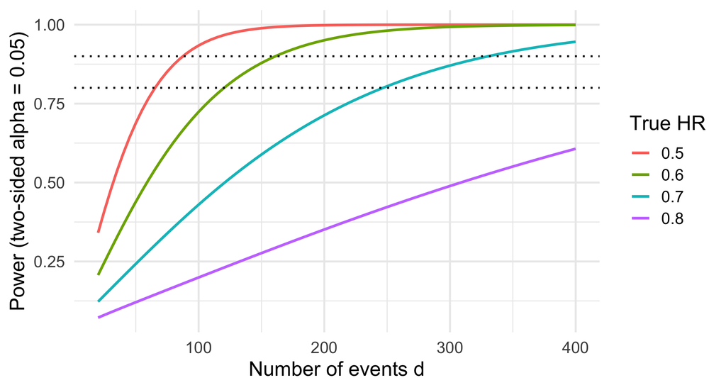

```r
power_fn <- function(d, hr, alpha = 0.05, p1 = 0.5) pnorm(sqrt(d * p1 * (1 - p1)) * abs(log(hr)) - qnorm(1 - alpha / 2))
expand_grid(d = seq(20, 400, by = 5), HR = c(0.5, 0.6, 0.7, 0.8)) |>
  mutate(power = power_fn(d, HR)) |>
  ggplot(aes(d, power, colour = factor(HR))) + geom_line(linewidth = 1) +
  geom_hline(yintercept = c(0.8, 0.9), linetype = 3) +
  labs(x = "Number of events d", y = "Power (two-sided alpha = 0.05)", colour = "True HR")
```

## Power as a function of the HR

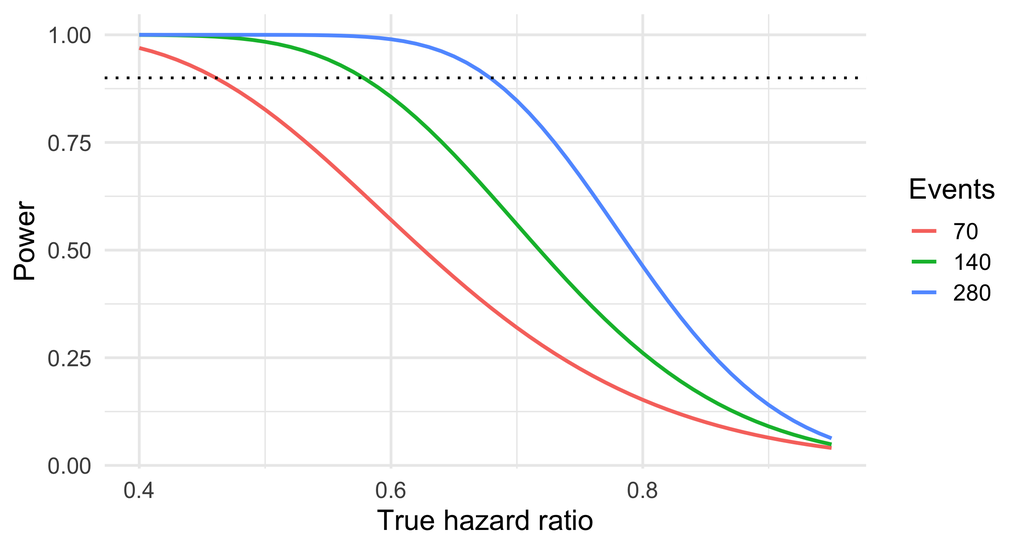

```r
expand_grid(HR = seq(0.4, 0.95, by = 0.01), d = c(70, 140, 280)) |>
  mutate(power = power_fn(d, HR)) |>
  ggplot(aes(HR, power, colour = factor(d))) + geom_line(linewidth = 1) +
  geom_hline(yintercept = 0.9, linetype = 3) +
  labs(x = "True hazard ratio", y = "Power", colour = "Events")
```

With the planned 140 events, power is 91% if the true HR is 0.57, but only 56% if it is 0.7. A trial that is powered for an optimistic effect is **underpowered** for a realistic one.

## Part C: pitfalls

- Choose $\psi_R$ as the **smallest clinically relevant** effect, not what you hope for
- Report all assumptions: $\alpha$, power, HR, control event rate, accrual, follow-up, drop-out, allocation
- Formulas assume proportional hazards and independent censoring
- Post hoc power calculation from an observed result is not informative: report a CI

## Think about (Part C)

1. Why does a long follow-up reduce the number of patients needed?
2. Reducing the expected HR from 0.57 to 0.78: by what factor does $d$ change? (Check with `schoenfeld`.)
3. A trial has 400 patients but only 60 deaths so far. Is it likely to be adequately powered for HR 0.6?

# Wrap-up

## What we skipped

- **Dependent (informative) censoring** (Chapter 14): what if censoring is related to prognosis? Sensitivity analyses and models for the censoring process.
- **Bayesian survival analysis** (Chapter 16): priors for $\beta$ and $h_0$, posterior inference, prediction.
- Also not covered today: multivariate/multi-state frailty models, joint models, group sequential designs.

## Take-home messages

**Important**

**Interval censoring.** The event is only known to lie in $(L, R]$; the likelihood contribution is $S(L) - S(R)$. Use Turnbull (`icenReg::ic_np`), `ic_sp` or `survreg(..., type = "interval2")` rather than midpoints or right endpoints.

**Important**

**Frailty.** Unobserved heterogeneity, shared within clusters, acts multiplicatively on the hazard. `coxph(... + frailty(id))` gives conditional HRs and a variance; `cluster(id)` gives marginal HRs with robust SE. Heterogeneity alone can make a population hazard decline.

**Important**

**Sample size.** Power depends on the number of **events**: $d = (z_{1-\alpha/2} + z_{1-\beta})^2 / (p_1 p_2 (\log \psi_R)^2)$. Convert to patients with $P(\text{event})$, which depends on accrual, follow-up and drop-out. Check by simulation.

**Next lecture**: repetition.

**Reading**: Collett, Chapter 9 (Sections 9.1-9.4), Chapter 10 (Sections 10.1-10.3 and 10.7, the shared frailty model; Example 10.4) and Chapter 15 (Sections 15.1-15.3).

## Self-check questions

1. Write the likelihood contribution for an exact, a right-censored, a left-censored and an interval-censored observation.
2. Why is KM on midpoints biased? In which direction does using the right endpoint bias $\hat S$?
3. What is the difference between `frailty(id)` and `cluster(id)` in `coxph`? Which one estimates a variance?
4. Why can a population hazard decrease although all individual hazards are constant?
5. Compute the number of events needed for HR 0.7, 80% power, $\alpha = 0.05$, equal allocation.
6. Name three design factors that determine the number of patients when the number of events is fixed.